# Aufgabenblatt 6

## Statistik für Wirtschaftsinformatiker, Übung, HTW Berlin

### Martin Spott, Michael Heimann, Shirin Riazy

Stand: 24.05.2023

## Wiederholung

- Was sind Varianz, Standardabweichung und Variationskoeffizient? Wie werden sie berechnet?
- Welche Fragestellung ist Gegenstand der Konzentrationsmessung einer Werteverteilung?
- Was wird mit einer Lorenzkurve dargestellt?
- Was ist der Gini-Koeffizient?

## Aufgabe 6.1 (Streuungsmaße)

Berechne die mittlere absolute Abweichung vom arithmetischen Mittel, die Varianz und die Standardabwei-chung für das Merkmal *Schluss* aus dem Datensatz `bmw.csv` von Aufgabenblatt 5.

1. Berechne die drei Maße händisch in R
2. Benutze die R-Funktionen `var()` und `sd()` für Varianz und Standardabweichung.

```r
bmw <- read.csv2("../bmw.csv", header= T, sep= ";", dec=".")
schlussWerte <- bmw$Schluss

arithMittel <- sum(schlussWerte)/length(schlussWerte)
arithMittel
```

```
[1] 33.88588
```

```r
var(schlussWerte)
```

```
[1] 0.6045888
```

```r
sd(schlussWerte)
```

```
[1] 0.7775531
```

```r
sqrt(var(schlussWerte))
```

```
[1] 0.7775531
```

**Beachte:** In R wird – wie bei den meisten anderen Statistikprogrammen – nicht die **empirische Varianz** (population variance) sondern die **Stichprobenvarianz** (sample variance) berechnet. Siehe in den Unterlagen zur Vorlesung nach, um den Unterschied herauszufinden.

- Stichprobenvarianz
  - teilen durch n-1 statt n

## Aufgabe 6.2 (Variationskoeffizient)

Der Aktienkurs der Volkswagenaktie wies in einem Zeitraum von 250 Handelstagen bei einem Mittelwert von 174,56€ eine Standardabweichung von 10,28€ auf. Für den gleichen Zeitraum ermittelt man für die Aktie der BMW AG eine Standardabweichung 4,68€ bei einem Mittelwert von 36,96€.

Berechne die Variationskoeffizienten für die Volkswagenaktie und für die BMW-Aktie. Was sagen uns die Werte? Vergleiche die Variationskoeffizienten der beiden Aktien.

**Variationskoeffizient sagt relative streuung aus**

```r
bmwVariations <- 4.68 / abs(36.96)
vwVariation <- 10.28 / abs(174.56)
bmwVariations
```

```
[1] 0.1266234
```

```r
vwVariation
```

```
[1] 0.05889093
```

## Aufgabe 6.3 (Lorenzkurve)

Für das Jahr 2012 wurde folgende Statistik der Neuzulassungen für PKW veröffentlicht (Quelle: http://www.kfz-auskunft.de/kfz/pkw_neuzulassungen_hersteller_2012.html)

| Hersteller | Stueckzahl |
| --- | --- |
| VW | 672921 |
| BMW | 284494 |
| Mercedes | 283006 |
| Audi | 266582 |
| Opel | 213627 |
| Ford | 206128 |
| Renault | 150740 |
| Skoda | 147197 |
| Hyundai | 100875 |
| Toyota | 83834 |

Erarbeite mit diesen Daten eine Lorenzkurve, ohne das R-Paket zu nutzen. Füge dazu die folgenden Spalten als Hilfe zu, die wir auch in der Vorlesung im Beispiel mit den Einrichtungshäusern benutzt haben:

- $i$: Index, nach aufsteigenden Einheiten sortiert
- $h_i$: absolute Häufigkeit des Herstellers, also $h_i = 1$ für alle $i$
- $f_i$: relative Häufigkeit des Herstellers
- $F_i$: kumulierte relative Häufigkeit des Herstellers
- $h_i^* = \textit{Stueckzahl}_i$: Stückzahl des Herstellers $i$
- $f_i^* = h_i^* / \sum_{j=1}^{10} h_j^*$: Einheiten jedes Herstellers relativ zur Summe aller Einheiten
- $F_i^*$ sind die $f_i^*$ kumuliert.

Welche beiden Spalten zeigt die Lorenzkurve? Zeichne die Lorenzkurve mit der Funktion `plot()`.

[output not shown]

## Aufgabe 6.4 (Lorenzkurve)

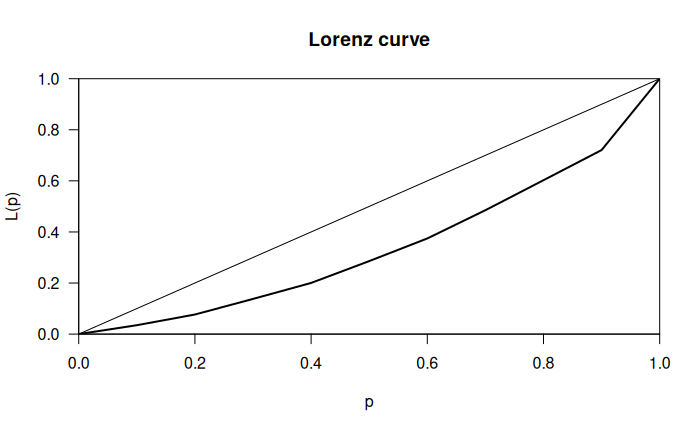

## Aufgabe 6.5 (Gini-Koeffizient)

1. Bestimme für die Daten aus Aufgabe 6.4 den Gini-Koeffizienten mit dem R-Paket `ineq` sowie den normierten Gini-Koeffizienten. Betrachte dazu die Funktionen `ineq()` und `Gini()`.
2. Warum ist es im Allgemeinen sinnvoll, neben dem Gini-Koeffizienten auch die Lorenzkurve zu betrachten?

```r
Gini(zulassungen$Stueckzahl)
```

```
[1] 0.31631
```

## Aufgabe 6.6 (Zusatzaufgabe)

Ergänze:

Besitzen alle Merkmalsträger denselben Merkmalswert, dann liegt eine ___ Konzentration vor. Auf 20% entfallen ___ % der Merkmalswertsummen, auf 40% entfallen ___ % der Merkmalswertsummen usw. Die Lorenzkurve und die Diagonale sind in diesem Fall ___ und die Fläche zwischen beidem ist gleich ___.

Vereinigt ein einziger Merkmalsträger die gesamte Merkmalswertsumme auf sich, so spricht man von ___ Konzentration. Je näher die Lorenzkurve zur Diagonalen liegt, desto ___ ist die Konzentration. Je weiter entfernt die Lorenzkurve zur Diagonalen liegt, desto ___ ist die Konzentration.

Das Ausmaß der Ungleichheit, also bildlich die Abweichung von Diagonale und Lorenzkurve, wird auch als ___ bezeichnet.

## Aufgabe 6.7 (Zusatzaufgabe)

Bestimme für die Daten aus Aufgabe 4 den Gini-Koeffizienten ohne das R-Paket `ineq`, indem du die Fläche zwischen Lorenzkurve und Diagonale händisch in R berechnest.

## Aufgabe 6.8 (Zusatzaufgabe, arithm. Mittel und Standardabw., klassifizierte Daten)

**Wiederholung:** Für eine Häufigkeitstabelle kann man das gewichtete arithmetische Mittel von Daten $x_1, x_2, \dots x_n$ wie folgt berechnen:
$$\bar{x} = \frac{1}{n} (h_1 \, a_1 + h_2
\,a_2 + \cdots + h_k \,a_k)
=f_1 \, a_1 + f_2 \,a_2 + \cdots + f_k \,a_k$$
wobei die $n$ Daten $x_i$ nur die $k$ verschiedenen Werte $a_j$ mit absoluter bzw. relativer Häufigkeit $h_j$ bzw. $f_j$ annehmen.

Berechne näherungsweise das arithmetische Mittel und die Standardabweichung für die folgenden klassifizierten/gruppierten Daten. Benutze hierzu die obige Formel für das gewichtete arithmetische Mittel einer Häufigkeitstabelle. Ersetze die Werte $a_j$ durch die Mittelpunkte der Intervalle und verwende die unten gelisteten Spalten als Hilfstabelle für die Zwischenschritte.

Die Daten beschreiben die Lebensdauer von Bauteilen in Stunden gruppiert in folgende Intervalle:

```r
Intervall <- c("[300, 400)", "[400, 500)", "[500, 600)", "[600, 700)", "[700, 800)")
Haeufigkeit <- c(13, 25, 66, 58, 38)
lebensdauer <- data.frame(Intervall, Haeufigkeit)
kable(lebensdauer)
```

[output not shown]

Füge zur Berechnung folgende Spalten zu `lebensdauer` hinzu:

- $j$: der Index der Gruppe
- Intervallmitte $a_j$
- $f_j$: die relative Häufigkeit
- $f_j \cdot a_j$
- $a_j^2$
- $f_j \cdot a_j^2$

Warum kann man arithmetisches Mittel und Standardabweichung so nur näherungsweise berechnen?